# Gibbs sampler - Hoff’s book - Ch 6

install.packages(“coda”)

The data are wing lenght (in mm) of n=9 midges

The model: $Y_i$ are conditionally iid ${\mathcal N}(\theta,\sigma^2)$

Both $\theta$ and $\tau=1/\sigma^2$ are unknown; $\tau$ is the precision of the measurements

Prior: $\pi(\theta,\tau)= \pi(\theta)\cdot \pi(\tau)$

$\theta \sim {\mathcal N}(\mu_0, t_0^2)$ ($\mu_0$ is the mean, $t_0^2$ is the variance)

$\tau \sim gamma(\nu_0/2, (\nu_0 s_0^2)/2 )$ ($1/s_0^2$ is the prior mean)

```r
#Hyperparameters - fixed according to prior information
mu0<-1.9  ; t20<-0.95^2
s20<-.01 ; nu0<-1

1/s20
```

```
[1] 100
```

```r
#data
y<-c(1.64,1.70,1.72,1.74,1.82,1.82,1.82,1.90,2.08)
n<-length(y) ; mean.y<-mean(y) ; var.y<-var(y)
```

#### Generate a Gibbs sampler MCMC of S draws

```r
set.seed(1)
S<-1000
PHI<-matrix(nrow=S,ncol=2) # Define the matrix (2 columns and S rows)
                           # it contains simulated values of the BIVARIATE Gibbs sampler MC
PHI[1,]<-phi<-c( mean.y, 1/var.y) # Initial point of the chain
```

##### Gibbs sampling

```r
for(s in 2:S) {
# the bidim. vector phi contains the "current" value of the chain
# generate a new theta value from its full conditional
mun<-  ( mu0/t20 + n*mean.y*phi[2] ) / ( 1/t20 + n*phi[2] ) #updated mean
t2n<- 1/( 1/t20 + n*phi[2] ) #updated variance
phi[1]<-rnorm(1, mun, sqrt(t2n) )

# generate a new tau=1/sigma^2 value from its full conditional
nun<- nu0+n             # it does NOT change with the iteration
s2n<- (nu0*s20 + (n-1)*var.y + n*(mean.y-phi[1])^2 ) /nun #updated parameter
phi[2]<- rgamma(1, nun/2, nun*s2n/2)

PHI[s,]<-phi         }


PHI[1:10,]
```

```
          [,1]      [,2]
 [1,] 1.804444  59.24951
 [2,] 1.777542  64.64477
 [3,] 1.770015 109.45214
 [4,] 1.815045  40.09787
 [5,] 1.789247  61.01623
 [6,] 1.791618 113.01271
 [7,] 1.816766  44.79361
 [8,] 1.789824  49.94203
 [9,] 1.803917  92.74123
[10,] 1.832977  76.77135
```

First 3 iterations of Gibbs sampler

```r
par(mfrow=c(1,3),mar=c(2.75,2.75,.5,.5),mgp=c(1.70,.70,0))
m1<-1
plot( PHI[1:m1,],type="p",xlim=range(PHI[1:100,1]), ylim=range(PHI[1:100,2]),
       lty=1,col="gray",xlab=expression(theta),ylab=expression(tau))
text(  PHI[1:m1,1], PHI[1:m1,2], c(1:m1) )
```

```r
m1<-2
plot( PHI[1:m1,],type="l",xlim=range(PHI[1:100,1]), ylim=range(PHI[1:100,2]),
       lty=1,col="gray",xlab=expression(theta),ylab=expression(tau))
text(  PHI[1:m1,1], PHI[1:m1,2], c(1:m1) )
```

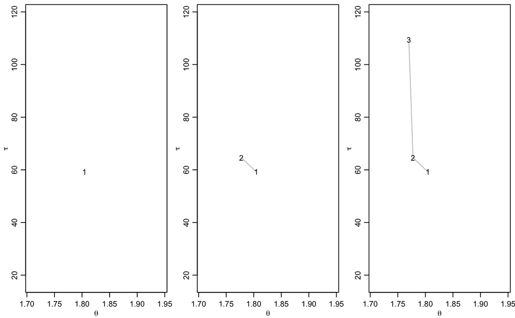

```r
m1<-3
plot( PHI[1:m1,],type="l",xlim=range(PHI[1:100,1]), ylim=range(PHI[1:100,2]),
       lty=1,col="gray",xlab=expression(theta),ylab=expression(tau))
text(  PHI[1:m1,1], PHI[1:m1,2], c(1:m1) )
```

First 100 iterations of the Gibbs sampler chain

```r
par(mfrow=c(1,3),mar=c(2.75,2.75,.5,.5),mgp=c(1.70,.70,0))
m1<-5
plot( PHI[1:m1,],type="l",xlim=range(PHI[1:100,1]), ylim=range(PHI[1:100,2]),
       lty=1,col="gray",xlab=expression(theta),ylab=expression(tau))
text(  PHI[1:m1,1], PHI[1:m1,2], c(1:m1) )
```

```r
m1<-15
plot( PHI[1:m1,],type="l",xlim=range(PHI[1:100,1]), ylim=range(PHI[1:100,2]),
       lty=1,col="gray",xlab=expression(theta),ylab=expression(tau))
text(  PHI[1:m1,1], PHI[1:m1,2], c(1:m1) )
```

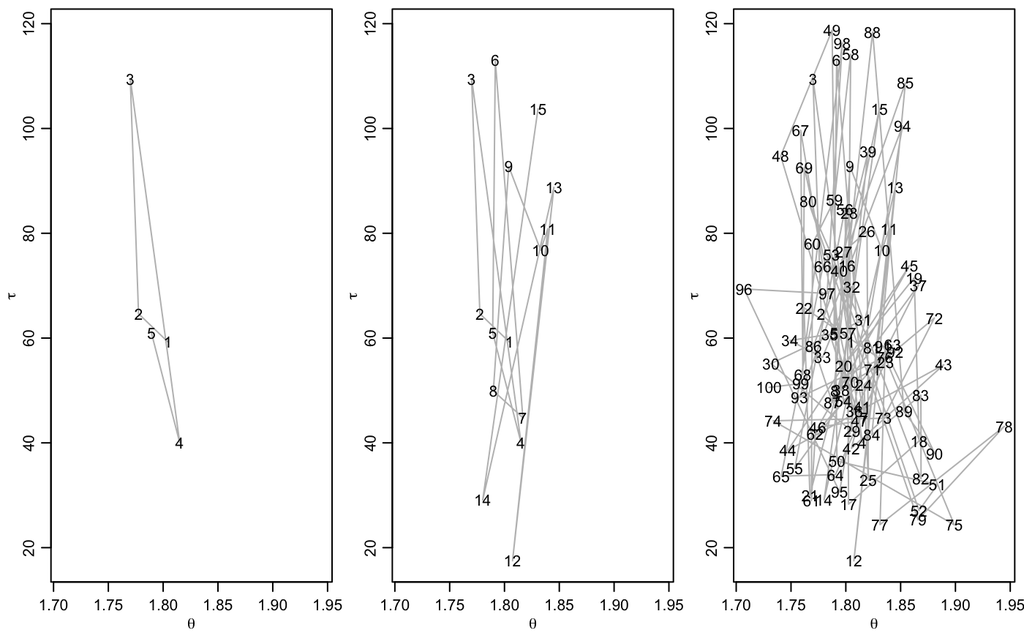

```r
m1<-100
plot( PHI[1:m1,],type="l",xlim=range(PHI[1:100,1]), ylim=range(PHI[1:100,2]),
       lty=1,col="gray",xlab=expression(theta),ylab=expression(tau))
text(  PHI[1:m1,1], PHI[1:m1,2], c(1:m1) )
```

Scatterplot

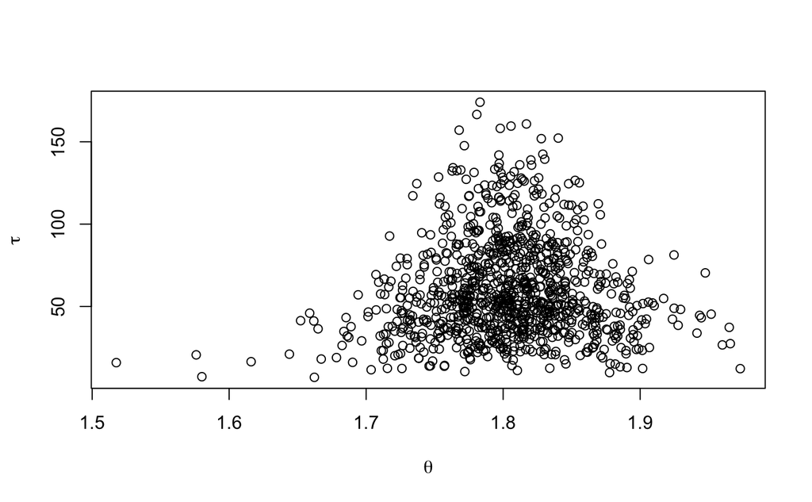

```r
sseq<-1:1000

plot(PHI[sseq,1],PHI[sseq,2],xlab=expression(theta), ylab=expression(tau) ,
     xlim=range(PHI[,1]),ylim=range(PHI[,2]))
```

PLOTS of the posterior marginal densities, with credibility intervals

```r
par(mfrow=c(1,2),mar=c(2.75,2.75,.5,.5),mgp=c(1.70,.70,0))
sseq<-1:1000

plot(density(PHI[,1],adj=2),  xlab=expression(theta),main="",
     xlim=c(1.55,2.05),
 ylab=expression( paste(italic("p("),
     theta,"|",italic(y[1]),"...",italic(y[n]),")",sep="")))
abline(v=quantile(PHI[,1],prob=c(.025,.975)),lwd=2,col="gray")
```

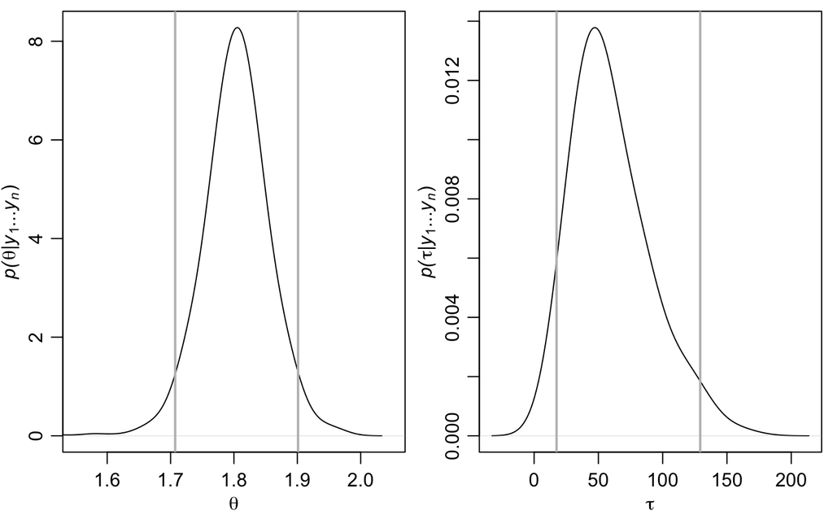

```r
plot(density(PHI[,2],adj=2), xlab=expression(tau),main="",
     ylab=expression( paste(italic("p("),
     tau,"|",italic(y[1]),"...",italic(y[n]),")",sep="")))
abline(v=quantile(PHI[,2],prob=c(.025,.975)),lwd=2,col="gray")
```

Credible intervals of unidimensional parameters

```r
quantile(PHI[,1],c(.025,.5,.975)) # Posterior CI of theta
```

```
    2.5%      50%    97.5%
1.707282 1.804348 1.901129
```

```r
quantile(PHI[,2],c(.025,.5, .975)) # Posterior CI of tau
```

```
     2.5%       50%     97.5%
 17.48020  53.62511 129.20020
```

```r
quantile(1/sqrt(PHI[,2]),c(.025,.5, .975))  # Posterior CI of sigma
```

```
      2.5%        50%      97.5%
0.08797701 0.13655763 0.23918408
```

marginal traceplots

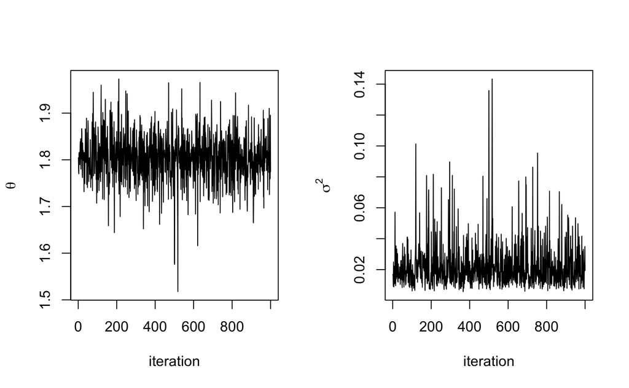

```r
par(mfrow=c(1,2))
plot(ts(PHI[,1]),xlab="iteration",ylab=expression(theta))
plot(ts(1/PHI[,2]),xlab="iteration",ylab=expression(sigma^2))
```

#### CONVERGENCE DIAGNOSTICS

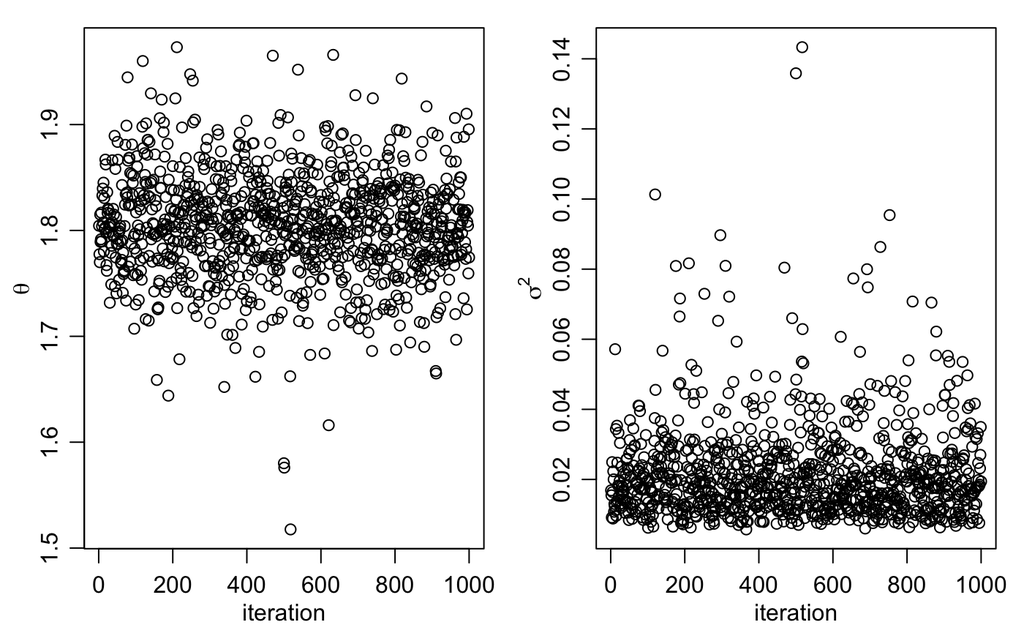

```r
par(mfrow=c(1,2))
par(mar=c(3,3,1,1),mgp=c(1.75,.75,0))
plot(PHI[,1],xlab="iteration",ylab=expression(theta))
plot(1/PHI[,2],xlab="iteration",ylab=expression(sigma^2))
```

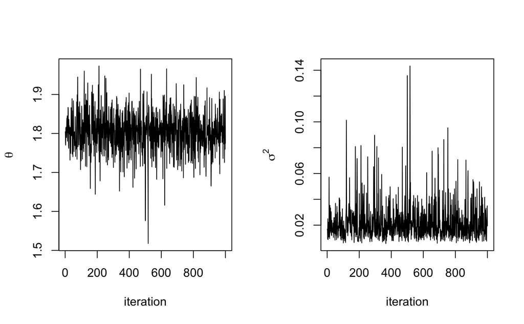

```r
par(mfrow=c(1,2))
plot(ts(PHI[,1]),xlab="iteration",ylab=expression(theta))
plot(ts(1/PHI[,2]),xlab="iteration",ylab=expression(sigma^2))
```

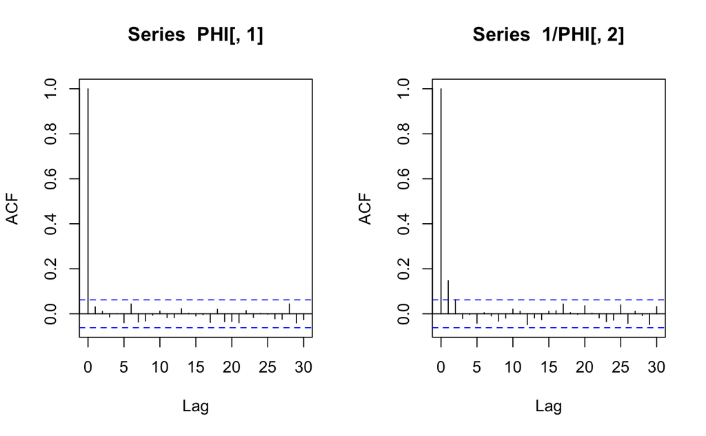

```r
library(coda)

par(mfrow=c(1,2))
acf(PHI[,1]) -> tmp1    #autocorrelation plot of theta
acf(1/PHI[,2]) -> tmp2  # autocorrelation plot of sigma^2
```

The Effective Sample Size (ESS) of a one-dimensional component of a MCMC is the number of INDEPENDENT iterations to achieve the same MCerror from the same marginal distribution of the MC (the stationary dist).

For a time series x of length N, the standard error of the mean is var(x)/n where n is the effective sample size. n = N only when there is no autocorrelation.

If the ESS is small (compared to the sample size of the chain), this means that the MC estimate will be rather ‘poor’, because the variance of the MC estimate will be ‘large’ wrt the variance of the Monte Carlo estimator.

The larger the ESS, the better!

```r
effectiveSize( PHI[,1] )
```

```
var1
1000
```

```r
effectiveSize(1/PHI[,2] )
```

```
    var1
742.6481
```